# Graphics in R: ggplot

2018.19 MICB405

Dr. Kim Dill-McFarland

version November 06, 2018

# Overview

In this tutorial, we will continue to work in the [tidyverse](https://www.tidyverse.org/), now venturing into plots and figures. Here, we cover:

- basics of ggplot
- scatterplots
- adding color and shape to plots

# Setup

You should open your `introR` R project and **start a new** working script `ggplot.R`. Since we are working in a new script, you should start it with packages and data loading!

Load packages  
**R v3.4 or newer**

```r
library(tidyverse)
```

**R v3.3 or older**

```r
library(readr)
library(dplyr)
library(tidyr)
library(ggplot2)
```

Load raw data

```r
raw_dat <- read_csv("Saanich_Data.csv")
```

Data cleaning

```r
dat <-
  raw_dat %>%
  select(Cruise, Date, Depth, Temperature,
         WS_O2, WS_NO3, WS_H2S) %>%
  filter(!is.na(WS_O2)) %>%
  rename(O2_uM=WS_O2, NO3_uM=WS_NO3, H2S_uM=WS_H2S) %>%
  mutate(Depth_m=Depth*1000)
```

# Data description

Using plots, we will investigate the relationship between **oxygen, nitrate, and hydrogen sulfide** in Saanich Inlet. We are particularly interested in these relationships, because oxygen is the most energetically favorable terminal electron acceptor for microbial metabolism in this system. However, oxygen is depleted in deeper waters as a result of the seasonal stratification.

So, what are microbes using to survive? As oxygen is depleted, microbes must use alternative terminal electron acceptors. In Saanich Inlet, nitrate is the next best option, so we want to see if nitrate is available to microbes when oxygen is depleted. We are also interested in hydrogen sulfide, because sulfate is the third best terminal electron acceptor in this system. If sulfate is being used, it will be reduced to hydrogen sulfide and we will see a build up of H2S when both oxygen and nitrate are depleted.

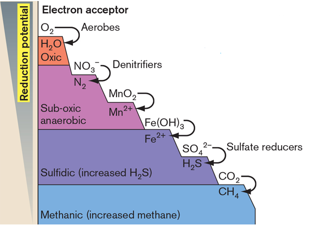

Let’s investigate these data to test these hypotheses by plotting the data!

# Graphics with ggplot2

*ggplot2* is an add-on package to R. It is an alternative to base graphics that has become very popular, to the point where it is recommended/preferred unless you have old code that already uses a different graphing package.

*ggplot2* documentation is available at [docs.ggplot2.org](http://docs.ggplot2.org/current/)

## Why ggplot?

- Wilkinson, *Grammar of Graphics* (1999)
- Ggplot2 is an implementation of GoG for R
- Benefits:
  - handsome default settings
  - snap-together building block approach
  - automatic legends, colors, facets
  - statistical overlays: regressions lines and smoothers (with confidence intervals)
- Drawbacks:
  - it can be hard to get it to look *exactly* the way you want
  - requires having the input data in a certain format

## ggplot building blocks

- data: 2D table (`data.frame`) of *variables*
- *aesthetics*: map variables to visual attributes (*e.g.* position)
- *geoms*: graphical representation of data (points, lines, etc.)
- *stats*: statistical transformations to get from data to points in the plot(binning, summarizing, smoothing)
- *scales*: control *how* to map a variable to an aesthetic
- *facets*: juxtapose mini-plots of data subsets, split by variable(s)
- *guides*: axes, legend, etc. reflect the variables and their values

Idea: independently specify and combine the blocks to create the plot you want.

There are at least three things we have to specify to create a plot:

1. data
2. aesthetic mappings from data variables to visual properties
3. a layer describing how to draw those properties